# Single Cell - Psiquiatria

# 7º - Análise diferencial

Uma das etapas mais importantes na análise de scRNA-seq é a identificação de genes diferencialmente expressos (DEGs) entre condições experimentais dentro de cada tipo celular. Para isso, três abordagens são amplamente utilizadas: o teste de Wilcoxon, o Model-based Analysis of Single-cell Transcriptomics (MAST) e a estratégia de pseudo-bulk.

O teste de Wilcoxon é o método padrão implementado no Seurat. Trata-se de um teste não paramétrico que compara a expressão gênica entre dois grupos de células, como controle e tratamento. Embora seja simples, rápido e amplamente utilizado, esse método considera as células como observações independentes, o que pode introduzir viés quando há predominância de células provenientes do mesmo indivíduo.

O MAST, por sua vez, foi desenvolvido especificamente para dados de célula única. Em geral, apresenta desempenho superior ao Wilcoxon, principalmente por permitir a inclusão de covariáveis no modelo estatístico, aumentando a robustez da análise.

Já a abordagem de pseudo-bulk consiste em agregar as contagens das células de um mesmo tipo celular por amostra, gerando perfis que podem ser analisados por métodos clássicos como o DESeq2. Atualmente, essa estratégia é considerada uma das mais robustas para comparações entre condições, pois reduz o problema da pseudorreplicação.

Para facilitar a compreensão, utilizaremos nesta aula o teste de Wilcoxon, por ser o mais simples e o padrão do Seurat. Ao final, mostramos como fazer a mesma comparação com o pseudo-bulk. Nesta etapa, identificaremos os genes diferencialmente regulados na depressão nos neurônios SST e PVALB do córtex.

Para separar esses neurônios, usaremos a classificação feita pelos autores (coluna `Cluster`), que já identifica as populações SST e PVALB.

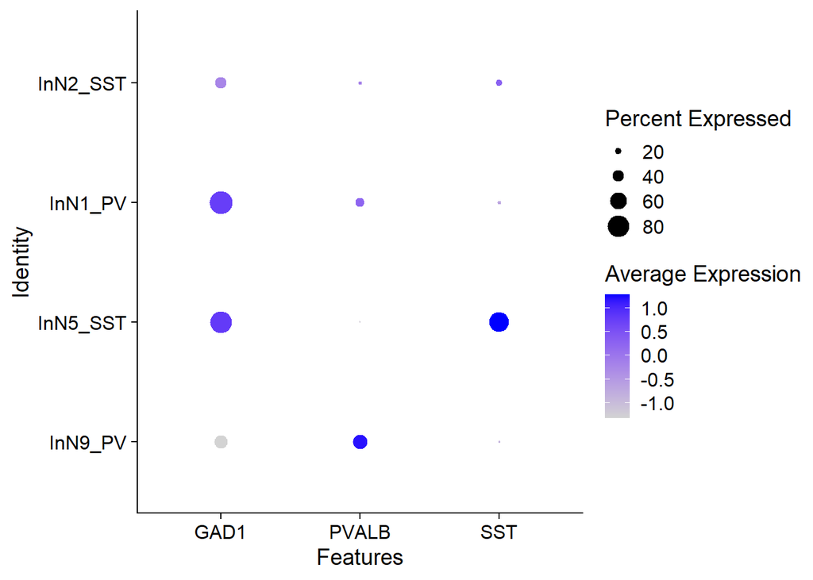

```r
#Identificação de populações inibitórias SST e PVALB
Idents(Data) = "Cluster"
DotPlot(Data, features = c("GAD1", "PVALB", "SST"),
        idents = c("InN2_SST", "InN5_SST", "InN1_PV", "InN9_PV"))
```

```r
#Isolar neurônios
SST = subset(Data, subset = Cluster %in% c("InN2_SST", "InN5_SST"))
Pvalb = subset(Data, subset = Cluster %in% c("InN1_PV", "InN9_PV"))

#Análise estatística

#SST
#Análise estatística, dizendo quais são os grupos comparados, o threshold de FoldChange, e a quantidade (%) mínima de células expressando o gene para que seja considerado significativo
Markers_SST = FindMarkers(SST, group.by = "Condition", ident.1 = "Case", ident.2 = "Control",
                          assay = "RNA", logfc.threshold = 0.2, min.pct = 0.2)
Markers_SST = subset(Markers_SST, subset = p_val_adj < 0.05) #Pegar apenas os significativos
Markers_SST = rownames_to_column(Markers_SST, "Gene") #Criar uma coluna para os rownames
Markers_SST$Cluster = "SST" #Adicionar uma coluna especificando que essa análise foi para os SST
write.xlsx(Markers_SST, "Marcadores_SST_Depressao.xlsx") #Salvar os DEGs
print(head(Markers_SST))
```

```
     Gene        p_val avg_log2FC pct.1 pct.2    p_val_adj Cluster
1    MEG3 5.408524e-33  0.7283834 0.995 0.979 1.978871e-28     SST
2 CNTNAP2 1.608670e-21 -0.4304246 0.949 0.981 5.885800e-17     SST
3   CADM2 7.697089e-18 -0.6344753 0.690 0.864 2.816211e-13     SST
4    DLG2 9.071971e-16 -0.4594568 0.800 0.915 3.319253e-11     SST
5  ADGRB3 5.875773e-13 -0.4221947 0.789 0.932 2.149828e-08     SST
6   UCHL1 2.159635e-12  1.1111817 0.490 0.353 7.901672e-08     SST
```

```r
#PVALB
Markers_Pvalb = FindMarkers(Pvalb, group.by = "Condition", ident.1 = "Case", ident.2 = "Control",
                            assay = "RNA", logfc.threshold = 0.2, min.pct = 0.2)
Markers_Pvalb = subset(Markers_Pvalb, subset = p_val_adj < 0.05) #Pegar apenas os significativos
Markers_Pvalb = rownames_to_column(Markers_Pvalb, "Gene") #Criar uma coluna para os rownames
Markers_Pvalb$Cluster = "PVALB" #Adicionar uma coluna especificando que essa análise foi para os PVALB
write.xlsx(Markers_Pvalb, "Marcadores_PVALB_Depressao.xlsx") #Salvar os DEGs
print(head(Markers_Pvalb))
```

```
        Gene        p_val avg_log2FC pct.1 pct.2    p_val_adj Cluster
1        TDG 2.993651e-26  1.8007015 0.563 0.254 1.095317e-21   PVALB
2       XIST 1.090245e-22 -9.2803449 0.000 0.254 3.988988e-18   PVALB
3       MEG3 1.114766e-16  0.3798892 0.997 1.000 4.078705e-12   PVALB
4 AP001267.1 1.670563e-11 -1.3284444 0.192 0.400 6.112255e-07   PVALB
5        FTL 2.004327e-09 -0.7020452 0.484 0.635 7.333430e-05   PVALB
6      SRSF5 2.392312e-08  0.5086084 0.767 0.672 8.752992e-04   PVALB
```

```r
#Gene > Gene sendo testado
#p_val > Valor de P
#avg_log2FC > Valor de alteração Log2 (Case em relação ao Control)
#pct.1 > Porcentagem de células do grupo Case que expressam o gene
#pct.2 > Porcentagem de células do grupo Control que expressam o gene
#p_val_adj > Valor de P ajustado (Bonferroni)
#Cluster > Cluster sendo testado
```

## Outra opção: pseudo-bulk

No pseudo-bulk, somamos as contagens de todas as células de cada pessoa. Assim, cada pessoa vira uma “amostra”, e a comparação passa a ser entre 3 casos e 5 controles, e não entre milhares de células. Abaixo, seguimos o mesmo modelo da vinheta de expressão diferencial do Seurat.

```r
#Somar as contagens por pessoa e condição
SST_pb = AggregateExpression(SST, assays = "RNA", return.seurat = TRUE, group.by = c("Condition", "Sample"))
Idents(SST_pb) = "Condition"

#Teste com DESeq2 (Case vs Control)
PB_SST = FindMarkers(SST_pb, ident.1 = "Case", ident.2 = "Control", test.use = "DESeq2")
PB_SST = subset(PB_SST, subset = p_val_adj < 0.05)
print(head(PB_SST))
```

```
[1] p_val      avg_log2FC pct.1      pct.2      p_val_adj
<0 linhas> (ou row.names de comprimento 0)
```

```r
#Comparar: quantos genes cada método encontrou nos neurônios SST?
c(Wilcoxon = nrow(Markers_SST), PseudoBulk = nrow(PB_SST))
```

```
  Wilcoxon PseudoBulk
        58          0
```

Com apenas 8 pessoas, é esperado que o pseudo-bulk encontre bem menos genes que o Wilcoxon. Isso acontece porque o Wilcoxon trata cada célula como uma réplica independente, o que torna os valores de p artificialmente pequenos.

# 8º - Ontologia Genética

Após a identificação dos DEGs, uma etapa comum é a realização da análise de ontologia gênica, que busca identificar os principais processos biológicos e vias associados aos genes encontrados. Essa análise pode ser conduzida de diferentes formas, entre elas o Over-Representation Analysis (ORA) e o Gene Set Enrichment Analysis (GSEA). Neste exemplo, utilizaremos o ORA por meio do pacote clusterProfiler.

Como “universo” (background), usamos os genes expressos na população analisada, ou seja, os genes que tinham chance de aparecer como DEG.

```r
library(clusterProfiler)
library(org.Hs.eg.db)

#SST
## Background utilizado: genes detectados em pelo menos 10% dos neurônios SST
Background = rownames(SST)[rowMeans(LayerData(SST, layer = "counts") > 0) >= 0.1]
Background = bitr(Background, fromType="SYMBOL",
                  toType="ENTREZID", OrgDb="org.Hs.eg.db") #Converter o símbolo do gene em código

Markers_SST = read.xlsx("Marcadores_SST_Depressao.xlsx") #Abrir os DEGs
Markers_SST = bitr(Markers_SST$Gene, fromType="SYMBOL",
                   toType="ENTREZID", OrgDb="org.Hs.eg.db") #Converter o símbolo do gene em código

GO_SST = enrichGO(gene = Markers_SST$ENTREZID,
                  universe = Background$ENTREZID,
                  OrgDb         = org.Hs.eg.db,
                  ont           = "BP",
                  pAdjustMethod = "BH",
                  pvalueCutoff  = 0.05,
                  qvalueCutoff  = 0.05,
                  readable      = TRUE) #Rodar a análise de ontologia genética para processos biológicos (BP)
GO_SST = data.frame(GO_SST@result) %>% filter(p.adjust < 0.05)
write.xlsx(GO_SST,"GO_SST.xlsx")
print(head(GO_SST))
```

```
                   ID                Description GeneRatio  BgRatio RichFactor
GO:0098609 GO:0098609         cell-cell adhesion     17/50 170/2855 0.10000000
GO:0007155 GO:0007155              cell adhesion     19/50 279/2855 0.06810036
GO:0099560 GO:0099560 synaptic membrane adhesion      4/50  16/2855 0.25000000
           FoldEnrichment oddsRatio   zScore       pvalue     p.adjust
GO:0098609        5.71000  8.929293 8.453154 1.191927e-09 1.218149e-06
GO:0007155        3.88853  5.999380 6.780343 6.584859e-08 3.364863e-05
GO:0099560       14.27500 20.239130 7.108163 1.298541e-04 4.423698e-02
                 qvalue
GO:0098609 4.374029e-07
GO:0007155 1.208227e-05
GO:0099560 1.588425e-02
                                                                                                                                  geneID
GO:0098609              STXBP6/NEGR1/ADGRL3/EFNA5/DLG2/PTPRD/CADM2/ROBO1/ASTN2/TENM2/PCDH15/CNTN1/ARID1B/IL1RAPL1/PCDH11X/CTNNA2/PCDH11Y
GO:0007155 STXBP6/NEGR1/ADGRL3/EFNA5/DLG2/PTPRD/CADM2/ROBO1/ASTN2/TENM2/RELN/PCDH15/CNTN1/ARID1B/IL1RAPL1/PCDH11X/CTNNA2/CNTNAP2/PCDH11Y
GO:0099560                                                                                                    EFNA5/PTPRD/TENM2/IL1RAPL1
           Count
GO:0098609    17
GO:0007155    19
GO:0099560     4
```

```r
#PVALB
## Background utilizado: genes detectados em pelo menos 10% dos neurônios PVALB
Background = rownames(Pvalb)[rowMeans(LayerData(Pvalb, layer = "counts") > 0) >= 0.1]
Background = bitr(Background, fromType="SYMBOL",
                  toType="ENTREZID", OrgDb="org.Hs.eg.db") #Converter o símbolo do gene em código

Markers_PVALB = read.xlsx("Marcadores_PVALB_Depressao.xlsx") #Abrir os DEGs
Markers_PVALB = bitr(Markers_PVALB$Gene, fromType="SYMBOL",
                     toType="ENTREZID", OrgDb="org.Hs.eg.db") #Converter o símbolo do gene em código

GO_PVALB = enrichGO(gene = Markers_PVALB$ENTREZID,
                    universe = Background$ENTREZID,
                    OrgDb         = org.Hs.eg.db,
                    ont           = "BP",
                    pAdjustMethod = "BH",
                    pvalueCutoff  = 0.05,
                    qvalueCutoff  = 0.05,
                    readable      = TRUE) #Rodar a análise de ontologia genética para processos biológicos (BP)
GO_PVALB = data.frame(GO_PVALB@result) %>% filter(p.adjust < 0.05)
write.xlsx(GO_PVALB,"GO_PVALB.xlsx")
print(head(GO_PVALB))
```

```
 [1] ID             Description    GeneRatio      BgRatio        RichFactor
 [6] FoldEnrichment oddsRatio      zScore         pvalue         p.adjust
[11] qvalue         geneID         Count
<0 linhas> (ou row.names de comprimento 0)
```

# 9 - Referências:

- Maitra, M., Mitsuhashi, H., Rahimian, R. *et al.* Cell type specific transcriptomic differences in depression show similar patterns between males and females but implicate distinct cell types and genes. *Nat Commun* **14**, 2912 (2023). https://doi.org/10.1038/s41467-023-38530-5
- Heumos, L., Schaar, A.C., Lance, C. *et al.* Best practices for single-cell analysis across modalities. *Nat Rev Genet* **24**, 550–572 (2023). https://doi.org/10.1038/s41576-023-00586-w | https://www.sc-best-practices.org/preamble.html
- Amezquita, R.A., Lun, A.T.L., Becht, E. *et al.* Orchestrating single-cell analysis with Bioconductor. *Nat Methods* **17**, 137–145 (2020). https://doi.org/10.1038/s41592-019-0654-x | https://bioconductor.org/books/release/OSCA/
- Hao, Y., Stuart, T., Kowalski, M.H. *et al.* Dictionary learning for integrative, multimodal and scalable single-cell analysis. *Nat Biotechnol* **42**, 293–304 (2024). https://doi.org/10.1038/s41587-023-01767-y | https://satijalab.org/seurat/articles/get_started_v5_new
- Sciaraffa N, Gagliano A, Augugliaro L and Coronnello C (2025) Optimization of clustering parameters for single-cell RNA analysis using intrinsic goodness metrics. *Front. Bioinform.* 5:1562410. https://doi.org/10.3389/fbinf.2025.1562410